# 🗳️ Natural Language of Politics

> Romain Clement, 2022

Analyse des programmes des candidats à la présidentielle 2022 sous l'angle du traitement du langage naturel (NLP)

# 🎯 Objectifs

- Vision objective des programmes
- Eléments différenciants
- Affinités politiques

**... bonne excuse pour de la data, de l'IA et du NLP !**

# 🎲 Jouons un peu !

Connaissez-vous bien les programmes des candidats à l'élection présidentielle 2022 ?

Mettons à l'épreuve vos connaissances !

[figure not shown]

# 🙈 Qui est-ce ?

Devinez à quel candidat appartiennent ces programmes !

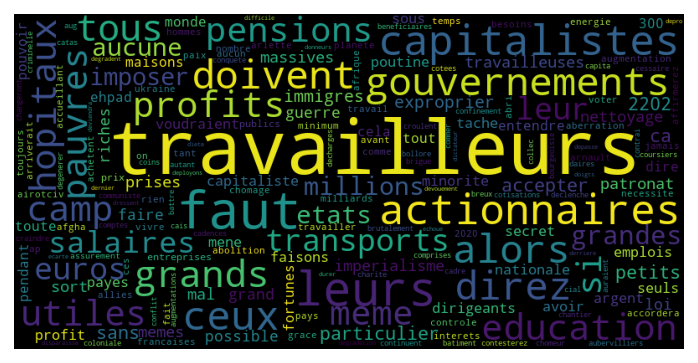

```
Madame Nathalie ARTHAUD
```

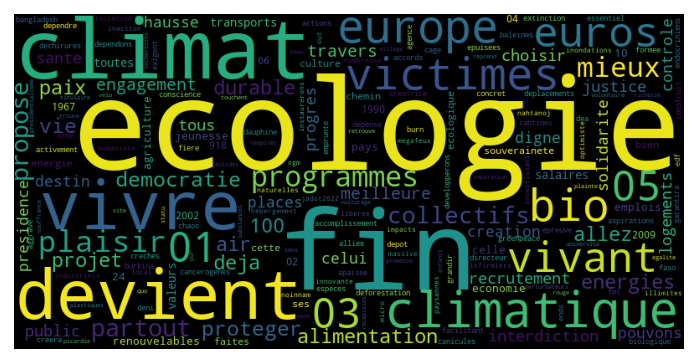

```
Monsieur Yannick JADOT
```

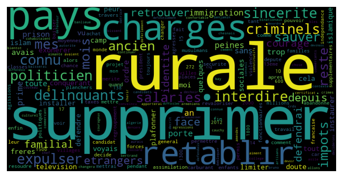

```
Monsieur Eric ZEMMOUR
```

# 🧑‍🤝‍🧑 Et plus si affinités

Quels sont les 3 "voisins" les plus proches de chaque candidat ?

```
Candidat : Monsieur Nicolas DUPONT-AIGNAN
```

```
Voisin 1 : Monsieur Eric ZEMMOUR
```

```
Voisin 2 : Madame Valerie PECRESSE
```

```
Voisin 3 : Madame Anne HIDALGO
```

```
Candidat : Monsieur Jean LASSALLE
```

```
Voisin 1 : Madame Anne HIDALGO
```

```
Voisin 2 : Madame Valerie PECRESSE
```

```
Voisin 3 : Monsieur Fabien ROUSSEL
```

```
Candidat : Monsieur Philippe POUTOU
```

```
Voisin 1 : Monsieur Fabien ROUSSEL
```

```
Voisin 2 : Madame Nathalie ARTHAUD
```

```
Voisin 3 : Monsieur Jean-Luc MELENCHON
```

|  | Candidat | Voisin 1 | Voisin 2 | Voisin 3 |
| --- | --- | --- | --- | --- |
| 0 | Madame Nathalie ARTHAUD | Monsieur Philippe POUTOU | Monsieur Fabien ROUSSEL | Madame Anne HIDALGO |
| 1 | Monsieur Nicolas DUPONT-AIGNAN | Monsieur Eric ZEMMOUR | Madame Valerie PECRESSE | Madame Anne HIDALGO |
| 2 | Madame Anne HIDALGO | Monsieur Fabien ROUSSEL | Monsieur Jean-Luc MELENCHON | Monsieur Yannick JADOT |
| 3 | Monsieur Yannick JADOT | Monsieur Fabien ROUSSEL | Madame Anne HIDALGO | Madame Valerie PECRESSE |
| 4 | Monsieur Jean LASSALLE | Madame Anne HIDALGO | Madame Valerie PECRESSE | Monsieur Fabien ROUSSEL |
| 5 | Madame Marine LE PEN | Monsieur Eric ZEMMOUR | Madame Anne HIDALGO | Madame Valerie PECRESSE |

|  | Candidat | Voisin 1 | Voisin 2 | Voisin 3 |
| --- | --- | --- | --- | --- |
| 6 | Monsieur Emmanuel MACRON | Madame Anne HIDALGO | Madame Valerie PECRESSE | Monsieur Fabien ROUSSEL |
| 7 | Monsieur Jean-Luc MELENCHON | Madame Anne HIDALGO | Monsieur Fabien ROUSSEL | Monsieur Philippe POUTOU |
| 8 | Madame Valerie PECRESSE | Madame Anne HIDALGO | Monsieur Eric ZEMMOUR | Monsieur Fabien ROUSSEL |
| 9 | Monsieur Philippe POUTOU | Monsieur Fabien ROUSSEL | Madame Nathalie ARTHAUD | Monsieur Jean-Luc MELENCHON |
| 10 | Monsieur Fabien ROUSSEL | Madame Anne HIDALGO | Monsieur Yannick JADOT | Monsieur Jean-Luc MELENCHON |
| 11 | Monsieur Eric ZEMMOUR | Madame Valerie PECRESSE | Madame Marine LE PEN | Madame Anne HIDALGO |

# 💡 Thématiques

Quels sont les principaux thèmes de cette campagne ?

## 5 thèmes principaux

|  | Terme 1 | Terme 2 | Terme 3 | Terme 4 | Terme 5 | Thematique |
| --- | --- | --- | --- | --- | --- | --- |
| 0 | vivre | europe | climat | ecologie | euros | ? |
| 1 | mes | veux | delinquants | pays | immigration | ? |
| 2 | ceux | capitalistes | profits | voulons | travailleurs | ? |
| 3 | europeenne | 20 | politique | liberons | suppression | ? |
| 4 | frontieres | voterez | confance | faisant | pacte | ? |

**Peut-on les nommer ?**

|  | Terme 1 | Terme 2 | Terme 3 | Terme 4 | Terme 5 | Thematique |
| --- | --- | --- | --- | --- | --- | --- |
| 0 | vivre | europe | climat | ecologie | euros | Ecologie |
| 1 | mes | veux | delinquants | pays | immigration | ? |
| 2 | ceux | capitalistes | profits | voulons | travailleurs | ? |
| 3 | europeenne | 20 | politique | liberons | suppression | ? |
| 4 | frontieres | voterez | confance | faisant | pacte | ? |

|  | Terme 1 | Terme 2 | Terme 3 | Terme 4 | Terme 5 | Thematique |
| --- | --- | --- | --- | --- | --- | --- |
| 0 | vivre | europe | climat | ecologie | euros | Ecologie |
| 1 | mes | veux | delinquants | pays | immigration | Sécurité |
| 2 | ceux | capitalistes | profits | voulons | travailleurs | ? |
| 3 | europeenne | 20 | politique | liberons | suppression | ? |
| 4 | frontieres | voterez | confance | faisant | pacte | ? |

|  | Terme 1 | Terme 2 | Terme 3 | Terme 4 | Terme 5 | Thematique |
| --- | --- | --- | --- | --- | --- | --- |
| 0 | vivre | europe | climat | ecologie | euros | Ecologie |
| 1 | mes | veux | delinquants | pays | immigration | Sécurité |
| 2 | ceux | capitalistes | profits | voulons | travailleurs | Economie |
| 3 | europeenne | 20 | politique | liberons | suppression | ? |
| 4 | frontieres | voterez | confance | faisant | pacte | ? |

|  | Terme 1 | Terme 2 | Terme 3 | Terme 4 | Terme 5 | Thematique |
| --- | --- | --- | --- | --- | --- | --- |
| 0 | vivre | europe | climat | ecologie | euros | Ecologie |
| 1 | mes | veux | delinquants | pays | immigration | Sécurité |
| 2 | ceux | capitalistes | profits | voulons | travailleurs | Economie |
| 3 | europeenne | 20 | politique | liberons | suppression | Europe |
| 4 | frontieres | voterez | confance | faisant | pacte | ? |

|  | Terme 1 | Terme 2 | Terme 3 | Terme 4 | Terme 5 | Thematique |
| --- | --- | --- | --- | --- | --- | --- |
| 0 | vivre | europe | climat | ecologie | euros | Ecologie |
| 1 | mes | veux | delinquants | pays | immigration | Sécurité |
| 2 | ceux | capitalistes | profits | voulons | travailleurs | Economie |
| 3 | europeenne | 20 | politique | liberons | suppression | Europe |
| 4 | frontieres | voterez | confance | faisant | pacte | Institution (?) |

# ⚙️ Pipeline

Comment automatiser l'analyse des programmes des candidats ?

## Etapes

1. Extraction de données : *web-scraping*, *extraction texte*, *SQLite*
2. Vectorisation du corpus : *tokenization*, *vectorization* (*TF-IDF*)
3. Analyses textuelles : *k-NN*, *NMF*, *PCA*

## Shéma Global

[figure not shown]

# 🧪 Conclusion

Résultats de cette expérimentation rapide ?

## Résultats encourageants

- Peu de pré-traitements nécessaires
- Représentations globalement en accord avec la perception
- Les mots semblent parler !

## Améliorations potentielles

- Données : programmes complets, transcriptions meetings
- Tokenisation : corrections orthographique, lemmatisation
- Vectorisation : n-grammes, plongements (*embeddings*)

# 📍 Un dernier pour la route ?

Seriez-vous capable de placer les candidats sur une carte ?

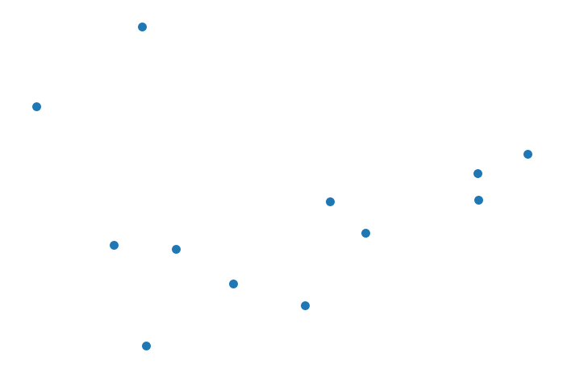

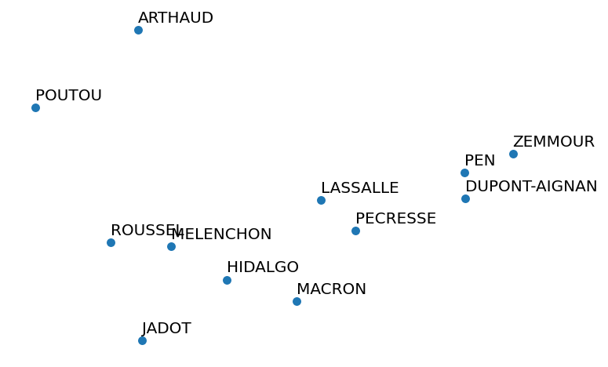

# 🙋 Questions

Merci pour votre attention ! Des questions ?

**Ressources**

- Dépôt GitHub : https://github.com/rclement/presidentielle-2022-nlp
- Programmes candidats : https://programme-candidats.interieur.gouv.fr
- Elections Tracker de Magic LEMP : https://www.elections-tracker.fr
- From Comments to Concepts: Text Analysis for Political Social Media Content (Paul Nulty) : https://www.youtube.com/watch?v=ww2RgDUwT-M

# ✉️ Contact

**Romain Clement**  
Data | IA | Formation  
https://romain-clement.net

[figure not shown]

*Scan this QR code to add my vCard to your contacts!*